# Homework 02

# HW 2 Solutions

Since there’s not really a single solution here, the code below just details some ways that you might approach this question.

# Libraries

```r
library(tidyverse)
library(tidycensus)   # census data
library(modelsummary) # model summaries
library(ggfortify)    # Additional descriptive plots
library(car)          # some additional diagnostics
library(labelled)     # add variable labels to data frame
```

# Getting Data

There’s a lot of code here, so I’ve folded it to get it out of the way. If you want to see the data manipulation here you can just click the arrow below

**Show data manipulation code**

```r
url<-"https://raw.githubusercontent.com/fivethirtyeight/election-results/main/election_results_presidential.csv"

presidential_elections<-read_csv(url)|>
  filter(office_name=="U.S. President" &  stage=="general")



# get the top two finishers for every previous cycle:
top_two_national <-presidential_elections|>
  filter(is.na(state))|>
  group_by(cycle)|>
  slice_max(votes, n=2)|>
  select(candidate_id, candidate_name, ballot_party)|>
  rename(national_party_affiliation = ballot_party)

# now calculate democratic vote share for every cycle
prior_voteshares <-presidential_elections|>
  filter(!str_detect(state, " CD-\\d+"))|>
  group_by(cycle)|>
  group_by(state,cycle, candidate_name)|>
  summarise(votes=sum(votes,na.rm =T))|>
  group_by(state,  cycle)|>
  # join with the data on the top two winners:
  right_join(top_two_national)|>
  select(national_party_affiliation, votes, state)|>
  pivot_wider(names_from = national_party_affiliation, values_from=votes)|>
  mutate(
    total_votes = DEM + REP,
    dem_percent = (DEM/total_votes) * 100)|>
  select(state, cycle, total_votes, dem_percent, DEM, REP)|>
  ungroup()|>
  group_by(state)|>
  arrange(cycle)|>
  mutate(prior_voteshare = lag(dem_percent))|>
  filter(cycle>=2012)


census_vars<-c(median_income = "B19013_001",
                           pop = "B01001_001",
                           race_pop = "B02001_001",
                           white_pop = "B02001_002",
                           black_pop = "B02001_003",
                           bachelors_degree = "B15003_022",
                           masters_degree = 'B15003_023',
                           professional_degree = 'B15003_024',
                           doctorate_degree = 'B15003_025',
                           over_25_total = 'B15003_001')
# bringing in some additional census data - lagged to prior year for consistency
years<-c(2011, 2015, 2019, 2023)

census_data<-map_dfr(years,
  ~ get_acs(geography = "state",
          variables = census_vars,
          survey="acs1",
                       year = .x)|>
  select(-moe)|>
  pivot_wider(names_from= variable, values_from=estimate)|>
  # so we can join this with the next year's vote totals
  mutate(year_to_join = .x + 1)

  )

# joining and calculating proportions
census_data<-census_data|>
  mutate(bachelors_or_over = ((bachelors_degree +
                                 masters_degree +
                                 professional_degree +
                                 doctorate_degree)/over_25_total)  * 100,
         white_percent = (white_pop /race_pop) * 100,
         income_1k = median_income/1000
         )


# joining with vote shares data
vote_data <- prior_voteshares|>
  left_join(census_data, by=join_by(state == NAME, cycle == year_to_join))


vote_data <- set_variable_labels(vote_data,
                              "DEM" = "total D votes",
                              "REP" = "total R votes",
                              "total_votes" = "Total votes in this election",
                              "dem_percent" = "Dem % share of two-party vote",
                              "prior_voteshare" = "Dem % in previous election",
                              'white_percent' = "% white",
                              'bachelors_or_over'  ="% bachelor's degree or greater",
                              'income_1k' = "median income ($1,000)"
                               )|>
  drop_na()|>
  ungroup()

# get 2020 data
vote_data_2020<-vote_data|>
  filter(cycle==2020)

# get 2024 data
vote_data_2024<-vote_data|>
  filter(cycle==2024)
```

# Descriptive Statistics

You could provide any number of descriptive stats here. A relatively easy (although not necessarily visually appealing) option is to use the `ggpairs` plot from `GGalley`:

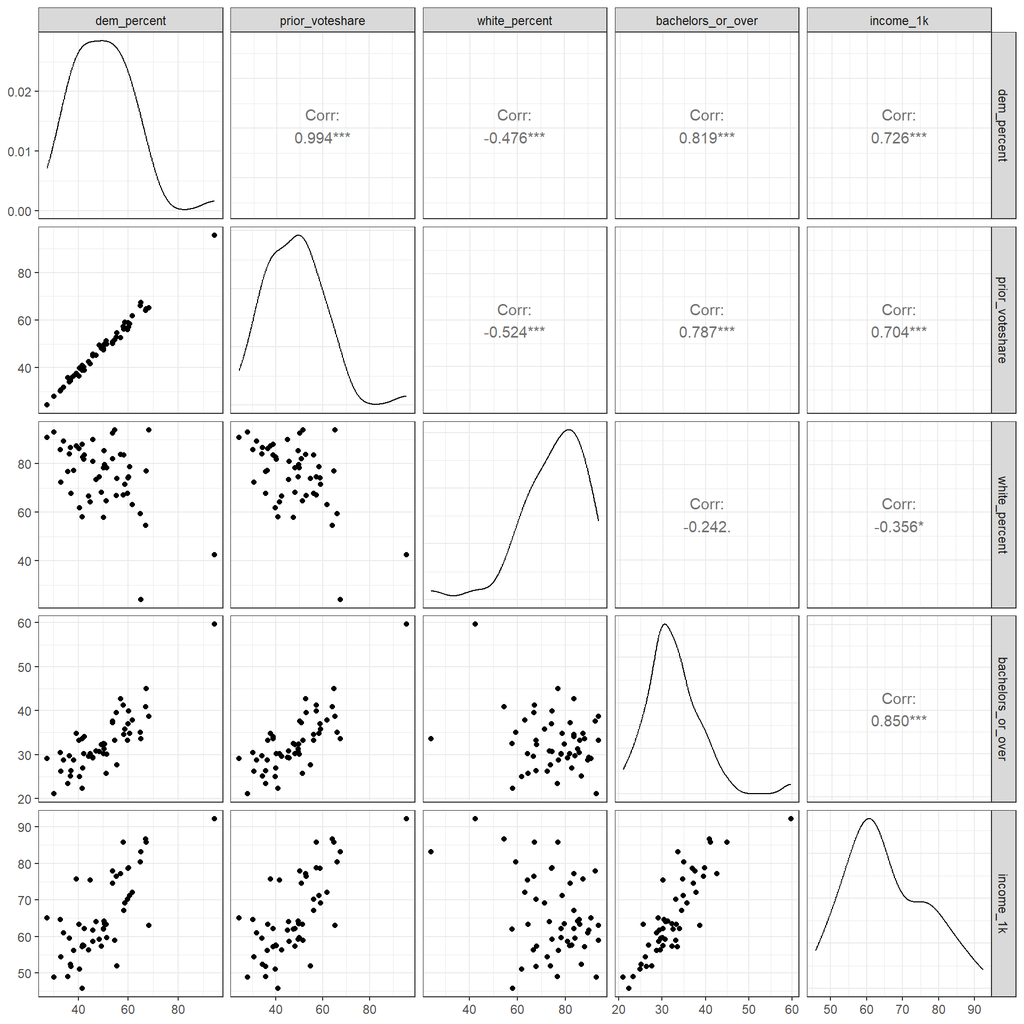

```r
vote_data_2020|>
  select(dem_percent, prior_voteshare, `white_percent`, `bachelors_or_over`, `income_1k`)|>
  GGally::ggpairs(progress=FALSE)+
  theme_bw()
```

# Models

I’ve estimated 4 different variants of the predictive model here so I can compare them.

```r
model_1 <- lm(dem_percent ~  prior_voteshare,
              data=vote_data_2020)
model_2 <- lm(dem_percent ~  prior_voteshare + income_1k,
              data=vote_data_2020)
model_3 <- lm(dem_percent ~  prior_voteshare +  income_1k + white_percent,
              data=vote_data_2020)
model_4 <- lm(dem_percent ~
                prior_voteshare + income_1k + white_percent + bachelors_or_over,
              data=vote_data_2020)

model_list<-list('model 1' = model_1,
                 'model 2' = model_2,
                 'model 3' = model_3,
                 'model 4' = model_4)
modelsummary(model_list,
             coef_rename=TRUE,
             coef_omit = "Intercept",
              estimate  = "{estimate}",
             statistic = c("conf.int"),
             conf_level = .95,
             note = "95% CI in brackets",
             )
```

|  | model 1 | model 2 | model 3 | model 4 |
| --- | --- | --- | --- | --- |
| Dem % in previous election | 0.956 | 0.921 | 0.953 | 0.919 |
|  | [0.926, 0.986] | [0.881, 0.961] | [0.914, 0.991] | [0.873, 0.966] |
| median income ($1,000) |  | 0.057 | 0.055 | 0.010 |
|  |  | [0.011, 0.103] | [0.015, 0.096] | [-0.044, 0.065] |
| % white |  |  | 0.055 | 0.041 |
|  |  |  | [0.028, 0.083] | [0.012, 0.070] |
| % bachelor's degree or greater |  |  |  | 0.132 |
|  |  |  |  | [0.020, 0.245] |
| Num.Obs. | 51 | 51 | 51 | 51 |
| R2 | 0.988 | 0.990 | 0.992 | 0.993 |
| R2 Adj. | 0.988 | 0.989 | 0.992 | 0.992 |
| AIC | 179.5 | 175.3 | 162.1 | 158.2 |
| BIC | 185.3 | 183.0 | 171.7 | 169.8 |
| Log.Lik. | -86.730 | -83.626 | -76.030 | -73.096 |
| F | 4097.595 | 2269.835 | 2001.273 | 1649.602 |
| RMSE | 1.33 | 1.25 | 1.07 | 1.01 |

95% CI in brackets

Just eyeballing the `AIC` and `BIC` values, it looks like the full model is probably the best performer. That said, we might also want to test out interaction terms or different combinations of the variables to see if there’s something more parsimonious.

## Model Diagnostics

We can get some basic model diagnostics using the `autoplot` function (for ggplot style) or just run `plot(model)` for base R graphics.

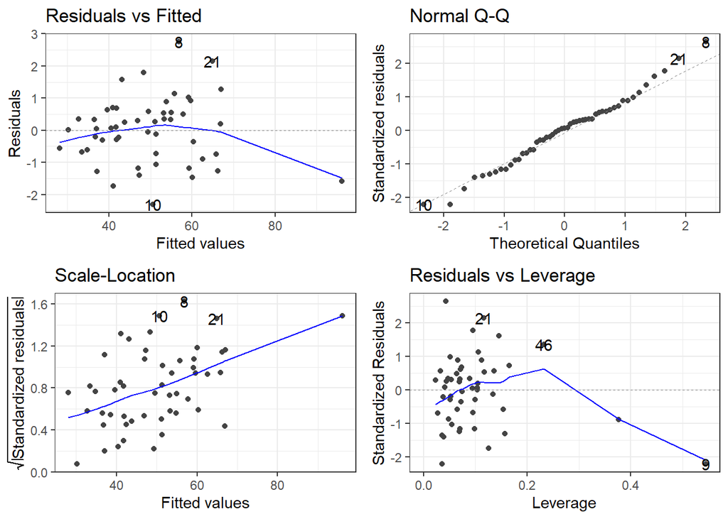

```r
autoplot(model_4) +
  theme_bw()
```

The results suggest we might have some heteroscedasticity, and a Breusch-Pagan also supports this hunch. This might be because our dependent variable is a proportion, so its variance depends on its mean:

```r
ncvTest(model_4)
```

```
Non-constant Variance Score Test
Variance formula: ~ fitted.values
Chisquare = 4.952177, Df = 1, p = 0.026058
```

One option here is to just use robust standard errors. We can use the `vcov` argument in the modelsummary function to change our standard error estimation procedure:

```r
modelsummary(model_list,
             coef_rename=TRUE,
             vcov='HC0',
             coef_omit = "Intercept",
              estimate  = "{estimate}",
             statistic = c("conf.int"),
             conf_level = .95,
             note = "95% CI in brackets",
             )
```

|  | model 1 | model 2 | model 3 | model 4 |
| --- | --- | --- | --- | --- |
| Dem % in previous election | 0.956 | 0.921 | 0.953 | 0.919 |
|  | [0.927, 0.985] | [0.881, 0.960] | [0.918, 0.987] | [0.878, 0.961] |
| median income ($1,000) |  | 0.057 | 0.055 | 0.010 |
|  |  | [0.011, 0.103] | [0.016, 0.094] | [-0.049, 0.070] |
| % white |  |  | 0.055 | 0.041 |
|  |  |  | [0.026, 0.084] | [0.014, 0.068] |
| % bachelor's degree or greater |  |  |  | 0.132 |
|  |  |  |  | [0.015, 0.249] |
| Num.Obs. | 51 | 51 | 51 | 51 |
| R2 | 0.988 | 0.990 | 0.992 | 0.993 |
| R2 Adj. | 0.988 | 0.989 | 0.992 | 0.992 |
| AIC | 179.5 | 175.3 | 162.1 | 158.2 |
| BIC | 185.3 | 183.0 | 171.7 | 169.8 |
| Log.Lik. | -86.730 | -83.626 | -76.030 | -73.096 |
| F | 4503.334 | 2214.225 | 3294.142 | 1656.650 |
| RMSE | 1.33 | 1.25 | 1.07 | 1.01 |
| Std.Errors | HC0 | HC0 | HC0 | HC0 |

95% CI in brackets

Alternatively, we could re-specify this as a logit model.

A `vif` statistic suggests we have a some multicolinearity here, but its important to keep this in perspective: if our goal is getting good predictions, this might not matter to us. If our goal is hypothesis testing, then we would still want to think very carefully before omitting variables that result in biased estimates.

```r
vif(model_4)
```

```
  prior_voteshare         income_1k     white_percent bachelors_or_over
         3.819640          3.960155          1.673086          5.839128
```

# Model selection for prediction

First, a warning:

**Warning**

If you’re trying to make predictions, this kind of model selection process **can be** helpful. However, if your goal is to test a hypothesis, it is probably bad practice because it has a good chance of generating false positives.

[See here for a quick simulation](https://raw.githubusercontent.com/Neilblund/GVPT728_Winter24/refs/heads/main/Additional%20Code%20and%20Data/model_selection_simulation.R), or see [this paper](https://bpspsychub.onlinelibrary.wiley.com/doi/10.1111/j.2044-8317.1992.tb00992.x) for a more in-depth exploration of the problem.

We can use the `step` function to perform automatic model selection. The step function will iteratively add or drop covariates and compare their AIC scores, and then select the best result. To include tests for the interactions between all covariates, I can add `scope = formula(~ .^2)` as an argument to this function:

```r
step_model <- step(model_4, direction = "both", scope = formula(~ .^2),
                   k= 2,
                   trace =FALSE # change to TRUE to view the output for each step
                   )

summary(step_model)
```

```
Call:
lm(formula = dem_percent ~ prior_voteshare + white_percent +
    bachelors_or_over + prior_voteshare:white_percent, data = vote_data_2020)

Residuals:
     Min       1Q   Median       3Q      Max
-2.42998 -0.41642 -0.01344  0.61366  2.65714

Coefficients:
                                Estimate Std. Error t value Pr(>|t|)
(Intercept)                    5.3923773  2.8817680   1.871  0.06768 .
prior_voteshare                0.7667423  0.0553513  13.852  < 2e-16 ***
white_percent                 -0.0699812  0.0390126  -1.794  0.07942 .
bachelors_or_over              0.1894713  0.0389490   4.865 1.38e-05 ***
prior_voteshare:white_percent  0.0018691  0.0006296   2.969  0.00474 **
---
Signif. codes:  0 '***' 0.001 '**' 0.01 '*' 0.05 '.' 0.1 ' ' 1

Residual standard error: 0.9801 on 46 degrees of freedom
Multiple R-squared:  0.9942,    Adjusted R-squared:  0.9937
F-statistic:  1961 on 4 and 46 DF,  p-value: < 2.2e-16
```

The results suggest including an interaction term for White X 2016 vote share can improve predictions further. I think the intuition here makes sense, but there’s also a risk that we’ll end up over-fitting to the data. Using the BIC statistic can mitigate this risk somewhat since it imposes a slightly stiffer penalty for extraneous covariates. I can do stepwise selection based on the BIC by changing `k` to equal $\ln(n)$, so:

```r
# get the sample size from our model data
n<-nrow(model_4$model)

bic_model <- step(model_4, direction = "both", scope = formula(~ .^2),
                   k = log(n),
                   trace =FALSE # change to TRUE to view the output for each step
                   )

summary(bic_model)
```

```
Call:
lm(formula = dem_percent ~ prior_voteshare + white_percent +
    bachelors_or_over + prior_voteshare:white_percent, data = vote_data_2020)

Residuals:
     Min       1Q   Median       3Q      Max
-2.42998 -0.41642 -0.01344  0.61366  2.65714

Coefficients:
                                Estimate Std. Error t value Pr(>|t|)
(Intercept)                    5.3923773  2.8817680   1.871  0.06768 .
prior_voteshare                0.7667423  0.0553513  13.852  < 2e-16 ***
white_percent                 -0.0699812  0.0390126  -1.794  0.07942 .
bachelors_or_over              0.1894713  0.0389490   4.865 1.38e-05 ***
prior_voteshare:white_percent  0.0018691  0.0006296   2.969  0.00474 **
---
Signif. codes:  0 '***' 0.001 '**' 0.01 '*' 0.05 '.' 0.1 ' ' 1

Residual standard error: 0.9801 on 46 degrees of freedom
Multiple R-squared:  0.9942,    Adjusted R-squared:  0.9937
F-statistic:  1961 on 4 and 46 DF,  p-value: < 2.2e-16
```

The BIC version still gives us the same result, which is somewhat reassuring. That said, stepwise regression procedures have a tendency to overfit, resulting in high in-sample accuracy but low out-of-sample accuracy. We might try to mitigate this with cross validation, but a more realistic test would be to see which model performs better when predicting 2024 election results.

## Predictions on 2024 data

Since we pulled 2024 data, we can generate predictions from all 5 models and then select the best performer based on the residual sum of squares:

```r
model_list<-list('model 1' = model_1,
                 'model 2' = model_2,
                 'model 3' = model_3,
                 'model 4' = model_4,
                 'model 5' = step_model)
# iterate over the list of models and get predictions
preds<-model_list|>
  map(.f=~predict(.x, newdata=vote_data_2024, type='response'))|>
  bind_cols()|>
  # re-bind with actual vote data:
  bind_cols(vote_data_2024)|>
  select(starts_with('model'), dem_percent, state, cycle)

# convert data to long format
preds_frame<-preds|>
  pivot_longer(cols=starts_with('model'), names_to='model', values_to='prediction')

# calculate RSS and R
preds_frame|>
  group_by(model)|>
  summarise(rss = sum( (dem_percent - prediction)^2 ),
            mu  = mean(dem_percent),
            tss = sum( (dem_percent - mu) ^2 ),
            r2  =  1  - (rss/tss)
            )|>
  arrange(rss)
```

| model | rss | mu | tss | r2 |
| --- | --- | --- | --- | --- |
| model 1 | 820.8475 | 47.51057 | 7262.468 | 0.8869740 |
| model 4 | 873.2089 | 47.51057 | 7262.468 | 0.8797642 |
| model 3 | 913.5165 | 47.51057 | 7262.468 | 0.8742140 |
| model 5 | 957.2098 | 47.51057 | 7262.468 | 0.8681977 |
| model 2 | 1096.6736 | 47.51057 | 7262.468 | 0.8489944 |

Based on these results, the best performer is actually the simplified model, whereas model 5 (the model from the stepwise model selection) is the second worst.

## Using a logit link and a weighting variable

Since these are technically proportions, we might try using a logistic regression instead. We’ll get an error if we try to use the values of `dem_percent` as our dependent variable with a binomial link function, but we can pass the proportions instead with the `quasibinomial` link function to get what are effectively the same results.

We might also consider including a weighting variable for the number of total votes cast in a state. If we think that the effect of our predictor variables is consistent across states, this might be a sensible choice, since it means that we would treat states with more observations as being more informative for estimating the average effect of our IV on the outcome.

```r
model_6 <- glm(dem_percent/100 ~  prior_voteshare ,
                 data=vote_data_2020, family='quasibinomial',
               weight=total_votes)

# get predictions for 2024:
m6_preds<-predict(model_6, type='response', newdata=vote_data_2024)  * 100


# calculating R^2
mu<-mean(vote_data_2024$dem_percent)
rss <- sum( (vote_data_2024$dem_percent - m6_preds)^2  )
tss<- sum(  (vote_data_2024$dem_percent - mu)^2  )
1 - (rss/tss)
```

```
[1] 0.9006386
```

Slight improvement! We still want to be careful about over-fitting here, but since there’s a good theoretical justify using a logit link instead of a gaussian, then this is probably fine.

## Using Elastic Net Regularization

Finally, we could also try using an [elastic net regularization model](https://www.stat.purdue.edu/~tlzhang/mathstat/ElasticNet.pdf), which does a kind of automatic variable selection by placing constraints around the total size of the vector of coefficients. Estimating a model requires us to specify a parameter $\lambda$ that will control the size of this constraint, but we can identify the “best” through cross-validation using the `cv.glmnet` function:

```r
library(glmnet)
mm2020<-vote_data_2020|>
  select( prior_voteshare, income_1k, white_percent, bachelors_or_over)|>
  model.matrix(~ 0 + .^2, data=_)

# run a cross-validation to select the best constraint value

cv<-cv.glmnet(y=vote_data_2020$dem_percent,
              x=mm2020,
              n=50
              )


best_lambda<-cv$lambda.1se
coef(cv, s=best_lambda)
```

```
11 x 1 sparse Matrix of class "dgCMatrix"
                                            s1
(Intercept)                       5.0882543134
prior_voteshare                   0.8392124408
income_1k                         .
white_percent                     .
bachelors_or_over                 0.1053101304
prior_voteshare:income_1k         .
prior_voteshare:white_percent     0.0002543615
prior_voteshare:bachelors_or_over .
income_1k:white_percent           .
income_1k:bachelors_or_over       .
white_percent:bachelors_or_over   .
```

```r
mm2024<-vote_data_2024|>
  select( prior_voteshare, income_1k, white_percent, bachelors_or_over)|>
  model.matrix(~ 0 + .^2, data=_)

# calculating residuals from best glmnet model:
preds<-predict(cv,s = best_lambda, newx=mm2024, type='response')
rss <- sum( (vote_data_2024$dem_percent -preds) ^2)

mu<-mean(vote_data_2024$dem_percent)

tss<- sum(  (vote_data_2024$dem_percent - mu)^2  )

1 - (rss/tss)
```

```
[1] 0.8793306
```

### Other things to try

For the sake of simplicity we just used state level data here, but we could potentially get more leverage by using multiple election cycles and/or using county-level data instead of the entire state. We might also want to explore some alternatives to logit/OLS for predicting proportional outcomes, and we might consider a wider range of covariates beyond just race, income, and education.

# General Feedback on Markdown Documents

I’ve spotted a couple of issues in markdown files that I think might be worth fixing. More than any specific advice, though, the most important thing is to just look at your output and ask yourself “is this readable?”, and try to fix it if it isn’t.

## Make things replicable

Go ahead and include the necessary code to replicate your results. If its messy and you don’t want to show it in the formatted output, then just set `include=FALSE` to keep that code chunk from appearing in your output and then include a copy of your .Rmd file in your homework submission along with your formatted file.

## Format and avoid printing entire data frames

Avoid printing data frames with a bunch of rows into a markdown document. Using the `head` function will automatically show the first `n` rows of output instead of printing everything.

```r
head(cars, n=4)
```

| speed | dist |
| --- | --- |
| 4 | 2 |
| 4 | 10 |
| 7 | 4 |
| 7 | 22 |

You can also add a `df_print` option to the header to automatically format data frame output. Default options here are `kable`, `tibble` or `paged`. (`paged` only works for HTML documents)

```
---
output:
  pdf_document:
    df_print: kable
---
```

See here for some additional information on [YAML options.](https://rstudio.github.io/cheatsheets/html/rmarkdown.html#set-output-formats-and-their-options-in-yaml)

## Suppress warning messages

Package loading tends to generate a lot of extraneous messages and warnings that aren’t really all that informative. You can suppress these for a single chunk by adding `message=FALSE` and `warning=FALSE` to that chunk of code:

````
```{r, message=FALSE, warning=FALSE}

# code that would normally generate a warning:
warning("help i'm bein suppressed")

```
````

Or you entire document by adding these options to the setup chunk at the top of the page:

````
```{r setup, include=FALSE }

knitr::opts_chunk$set(echo = TRUE, warning=FALSE, message=FALSE)

```
````

## Use `#` for headers

In R, you can use `#` for comments, but including a `#` outside of a code chunk will make a section heading.

````
# A Section Heading

Some regular text...

```{r}

# a comment inside my code chunk

```
````